# Homework 06-PCA_tSNE

Tanubrata Dey

12/3/2021

```
Sys.setenv("VROOM_CONNECTION_SIZE"=99999999)
readr::local_edition(1)
gse2109 = getGEO("GSE2109")
```

```
tissues = gse2109$GSE2109_series_matrix.txt.gz@phenoData@data$source_name_ch1
samples = rownames(gse2109$GSE2109_series_matrix.txt.gz@phenoData@data)
expvalues = exprs(gse2109$GSE2109_series_matrix.txt.gz)
```

```
write.table(cbind(samples,tissues), "Tissues.txt",
            row.names = F)
write.table(expvalues, "ExpressionValues.txt", col.names = NA)
```

The dataset we are using for this homework comes from the Expression project of Oncology. (https://www.ncbi.nlm.nih.gov/geo/query/acc.cgi?acc=gse2109) The project performed microarray analysis on over 2000 patients with cancer. Samples were taken from many different tissues. There are two goals for this assignment:

1. Identify genes that can help us distinguish the different types of cancer, and
2. Create a PCA and a tSNE plot using these genes to visually determine if we are successful.

To make our analysis easier, we will focus on : Breast, Colon, Kidney, and Lung.

## Step 0: Load the data

There are two files provided. - The ExpressionValues.txt contains a matrix where each row is a different probe identifier and every column is a different sample. Load this as **expvalues** - The Tissues.txt contains the tissue corresponding to the sample name. Load this as **tissues**

```r
library(readr)
expvalues <- read.csv("~/NYU classes/Fall 2021/BIOL-GA-2030/HW6/ExpressionValues.txt", row.names=1, sep="")
tissues <- read.csv("~/NYU classes/Fall 2021/BIOL-GA-2030/HW6/Tissues.txt", sep="")
```

## Step 1: Focus on a few specific tissues

Create a new data frames, call it **select_expvalues** and **select_tissues** to store the new, smaller sets.

```r
library(tidyverse)
select_tissues = filter(tissues, tissues == "Breast"| tissues == "Colon" | tissues == "Kidney" | tissues == "Lung")
```

```
select_expvalues = select(expvalues, select_tissues$samples %in% colnames(expvalues))
```

```r
select_expvalues = expvalues %>% select(one_of(dput(as.character(select_tissues$samples))))
```

[output not shown]

[output cut: 143 more lines]

[output not shown]

## Step 2: Determine differentially expressed genes

We want to identify genes whose expression are not the same in the different tissues we have selected. What statistical test is appropriate here? Explain your answer.

To identify genes that are differentially expressed, we could have used the t-test but the issue is t-test only works when there is 2 different groups to compare but in our case there are 4 (breast, colon, kidney, lung), so t-test cannot be done. For this reason, the best one to choose is ANOVA from where we can get p-values and then by FDR method we can adjust them and filter out the most significant genes based on lower p-values.

### Step 3: Perform the statistical test for each gene.

Save the pvalues of the test in a vector call pvalues.

```r
#############################################
anova3way.mk <- function(expvector, vector1)
#############################################
#
# INPUT 1: expvector = numerical vector
#  vector1 is a vector defining the first parameter.


{
# function is not assuming factors were provided so we just make sure here
  v1 = factor(vector1)

  temp.stats = numeric()

  # the model below is equivalent to v1 , however here we are explicit
  temp.lm=lm(expvector ~ v1)

  #probability of the model can be calculated by retrieving the values for
  # performing fstatistics
  temp.fstat=summary(temp.lm)$fstatistic
  temp.model.value = pf( temp.fstat[1] , temp.fstat[2] , temp.fstat[3] , lower.tail=F )

  return(temp.model.value)
}


pvalues = apply(select_expvalues, 1, anova3way.mk, select_tissues$tissues)
```

```r
head(as.data.frame(pvalues))
```

```
##                 pvalues
## 1007_s_at  1.034512e-10
## 1053_at    5.305483e-08
## 117_at     2.216957e-03
## 121_at    1.213269e-119
## 1255_g_at  2.096949e-02
## 1294_at    1.629944e-01
```

### Step 4: Adjust for multiple hypothesis testing

Use the p.adjust function to correct for multiple hypothesis testing uing the FDR method. Save these adjusted values as **adjpvalues**.

```r
adjpvalues = p.adjust(pvalues, method="fdr")
```

```r
head(as.data.frame(adjpvalues))
```

```
##              adjpvalues
## 1007_s_at  2.540626e-10
## 1053_at    1.089697e-07
## 117_at     2.980015e-03
## 121_at    1.408397e-117
## 1255_g_at  2.523622e-02
## 1294_at    1.767041e-01
```

## Step 5: Take the expression values of the 200 genes with lowest adjusted pvalue. Save this as **sig_values**

```r
pvalues_sorted = sort(adjpvalues, decreasing = F)

sig_values = select_expvalues[names(pvalues_sorted)[1:200],]

dim(sig_values)
```

```
## [1]  200 1048
```

## Step 6: Perform PCA using sig_values

Draw the PCA plot. Don’t forget, you can use the tissues column in the tissues data frame to add color so you can see how they have separated.

```r
data.prcomp = prcomp(t(sig_values), scale=TRUE, center=TRUE)

# your eigenvector is
head(data.prcomp$sdev)
```

```
## [1] 9.535798 6.510256 2.178462 1.749339 1.598918 1.543294
```

```r
data.prcomp$rotation[1:6,1:6]
```

```
##                     PC1         PC2          PC3          PC4           PC5
## 228780_at    0.08990677 -0.05502519 -0.051806910 -0.031070331  0.0003798958
## 203824_at   -0.06411485 -0.10292501 -0.009275410  0.004425322  0.0702876392
## 209847_at   -0.06316354 -0.10796929 -0.008324564 -0.002894362 -0.0010859723
## 219271_at    0.08859456 -0.04838958  0.001502161  0.063031112 -0.0166814187
## 228912_at   -0.05759151 -0.11298117  0.009901008 -0.029980548 -0.1251577597
## 218687_s_at -0.06190159 -0.10172306 -0.004518268  0.008788602  0.1317748597
##                      PC6
## 228780_at   -0.006152714
## 203824_at    0.029818821
## 209847_at   -0.027857003
## 219271_at    0.028296502
## 228912_at   -0.094446106
## 218687_s_at  0.034763685
```

```r
data.prcomp$x[1:6.1:6]
```

```
## [1]  -1.874224  -1.769774 -10.568856  -4.264037  -2.622880  -2.680517
```

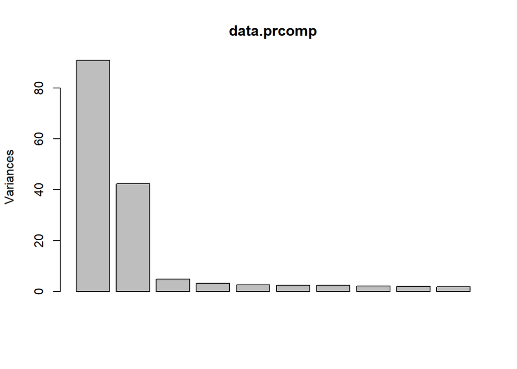

```r
plot(data.prcomp)
```

```r
#table of variance - shows proportion of variance
summary(data.prcomp)
```

```
## Importance of components:
##                           PC1    PC2     PC3    PC4     PC5     PC6    PC7
## Standard deviation     9.5358 6.5103 2.17846 1.7493 1.59892 1.54329 1.5169
## Proportion of Variance 0.4547 0.2119 0.02373 0.0153 0.01278 0.01191 0.0115
## Cumulative Proportion  0.4547 0.6666 0.69030 0.7056 0.71839 0.73030 0.7418
##                            PC8     PC9    PC10    PC11    PC12    PC13    PC14
## Standard deviation     1.43410 1.36974 1.32243 1.17301 1.08761 1.05494 1.03059
## Proportion of Variance 0.01028 0.00938 0.00874 0.00688 0.00591 0.00556 0.00531
## Cumulative Proportion  0.75208 0.76146 0.77021 0.77709 0.78300 0.78857 0.79388
##                           PC15    PC16    PC17    PC18    PC19    PC20    PC21
## Standard deviation     1.00750 0.99817 0.97263 0.93537 0.92656 0.90929 0.90113
## Proportion of Variance 0.00508 0.00498 0.00473 0.00437 0.00429 0.00413 0.00406
## Cumulative Proportion  0.79895 0.80393 0.80866 0.81304 0.81733 0.82147 0.82553
##                           PC22    PC23    PC24    PC25    PC26   PC27    PC28
## Standard deviation     0.88951 0.85290 0.84321 0.82710 0.80700 0.8006 0.79621
## Proportion of Variance 0.00396 0.00364 0.00356 0.00342 0.00326 0.0032 0.00317
## Cumulative Proportion  0.82948 0.83312 0.83667 0.84009 0.84335 0.8466 0.84973
##                           PC29    PC30    PC31   PC32    PC33    PC34    PC35
## Standard deviation     0.77903 0.76777 0.75722 0.7478 0.74167 0.72865 0.71503
## Proportion of Variance 0.00303 0.00295 0.00287 0.0028 0.00275 0.00265 0.00256
## Cumulative Proportion  0.85276 0.85571 0.85857 0.8614 0.86412 0.86677 0.86933
##                          PC36    PC37    PC38    PC39    PC40    PC41   PC42
## Standard deviation     0.7072 0.70575 0.68970 0.67907 0.67473 0.66979 0.6634
## Proportion of Variance 0.0025 0.00249 0.00238 0.00231 0.00228 0.00224 0.0022
## Cumulative Proportion  0.8718 0.87432 0.87670 0.87901 0.88128 0.88353 0.8857
##                           PC43    PC44   PC45    PC46    PC47    PC48   PC49
## Standard deviation     0.65867 0.65379 0.6486 0.64650 0.63057 0.62247 0.6171
## Proportion of Variance 0.00217 0.00214 0.0021 0.00209 0.00199 0.00194 0.0019
## Cumulative Proportion  0.88790 0.89003 0.8921 0.89423 0.89621 0.89815 0.9001
##                           PC50    PC51    PC52    PC53    PC54    PC55    PC56
## Standard deviation     0.61254 0.60990 0.59828 0.59214 0.58566 0.58436 0.57650
## Proportion of Variance 0.00188 0.00186 0.00179 0.00175 0.00171 0.00171 0.00166
## Cumulative Proportion  0.90193 0.90379 0.90558 0.90733 0.90905 0.91076 0.91242
##                           PC57    PC58    PC59    PC60    PC61    PC62    PC63
## Standard deviation     0.57467 0.56951 0.56117 0.55987 0.55609 0.55381 0.54639
## Proportion of Variance 0.00165 0.00162 0.00157 0.00157 0.00155 0.00153 0.00149
## Cumulative Proportion  0.91407 0.91569 0.91727 0.91883 0.92038 0.92191 0.92341
##                           PC64    PC65   PC66   PC67    PC68    PC69    PC70
## Standard deviation     0.53730 0.53540 0.5299 0.5295 0.52370 0.52186 0.51703
## Proportion of Variance 0.00144 0.00143 0.0014 0.0014 0.00137 0.00136 0.00134
```

[output cut: 62 more lines]

```
## Standard deviation     0.17442 0.16959 0.16691 0.16073 0.15861 0.15583 0.15209
## Proportion of Variance 0.00015 0.00014 0.00014 0.00013 0.00013 0.00012 0.00012
## Cumulative Proportion  0.99812 0.99827 0.99841 0.99854 0.99866 0.99878 0.99890
##                         PC183  PC184   PC185   PC186   PC187   PC188   PC189
## Standard deviation     0.1407 0.1395 0.13420 0.12837 0.12420 0.12352 0.11860
## Proportion of Variance 0.0001 0.0001 0.00009 0.00008 0.00008 0.00008 0.00007
## Cumulative Proportion  0.9990 0.9991 0.99919 0.99927 0.99935 0.99942 0.99949
##                          PC190   PC191   PC192   PC193   PC194   PC195   PC196
## Standard deviation     0.11380 0.11252 0.10663 0.10440 0.10268 0.09330 0.09043
## Proportion of Variance 0.00006 0.00006 0.00006 0.00005 0.00005 0.00004 0.00004
## Cumulative Proportion  0.99956 0.99962 0.99968 0.99973 0.99978 0.99983 0.99987
##                          PC197   PC198   PC199   PC200
## Standard deviation     0.08910 0.08154 0.07921 0.07294
## Proportion of Variance 0.00004 0.00003 0.00003 0.00003
## Cumulative Proportion  0.99991 0.99994 0.99997 1.00000
```

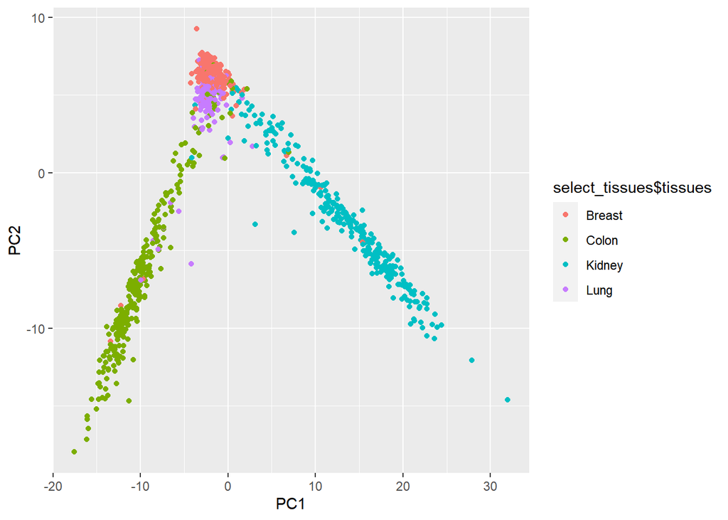

```r
library(dplyr)
library(ggplot2)
coords2draw = as.data.frame(data.prcomp$x)
coords2draw = cbind(coords2draw, select_tissues$tissues)

ggplot(coords2draw) +
  geom_point(mapping=aes(x = PC1, y= PC2, col = select_tissues$tissues))
```

## Step 7: Perform a tSNE

Use the tsne function in the M3C package to create a tSNE plot. Use a dotsize of 2 to make the figure easier to see.

```r
library(BiocManager)
BiocManager::install("M3C")
library(M3C)
```

```r
#distinct_data = distinct(select_expvalues)

tsne(select_expvalues, labels=select_tissues$tissues,
     perplex = 15, dotsize = 2)
```

```
## ***t-SNE wrapper function***
```

```
## running...
```

```
## done.
```

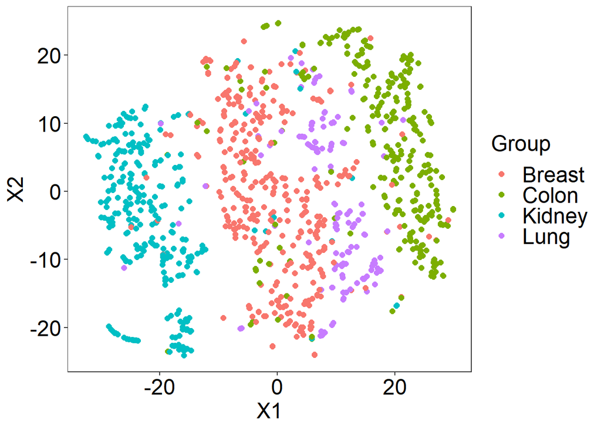

## Step 8: What have you learned?

Explain whether we were able to use our top 200 genes to separate the data based on the tissue source. Compare how useful PCA was versus tSNE.